# Specificity of Effects in DEV and MGR

Katie Paul Friedman

12/14/2023

# 1 Connections and Database Query

- Toxicity Reference Database (ToxRefDB) version 2.1 was released in September 2022.
- ToxRefDB v2.1 does not contain additional studies; it is a bug-fix release that added some dropped observations in some studies.

```r
con <- dbConnect(drv = RMySQL::MySQL(),
                 database=res_toxrefdb, # internal research MySQL database naming currently
                 user="", password="",host="") # user and host connection details omitted
```

```r
toxrefv2_1 <- dbGetQuery(con, "SELECT
                       chemical.chemical_id,
                       chemical.dsstox_substance_id,
                       chemical.casrn,
                       chemical.preferred_name,
                       study.study_id,
                       study.processed,
                       study.study_type,
                       study.study_year,
                       study.study_source,
                       study.species,
                       study.strain_group,
                       study.admin_route,
                       study.admin_method,
                       study.substance_purity,
                       endpoint.endpoint_category,
                       endpoint.endpoint_type,
                       endpoint.endpoint_target,
                       endpoint.endpoint_id,
                       tg_effect.life_stage,
                       tg_effect.tg_effect_id,tg_effect.target_site,
                       effect.effect_id,
                       effect.effect_desc,
                       effect.cancer_related,
                       tg.sex,
                       tg.generation,
                       tg.n,
                       tg.dose_duration,
                       tg.dose_duration_unit,
                       dose.vehicle,
                       dose.dose_level,
                       dtg.dose_adjusted,
                       dtg.dose_adjusted_unit,
                       dtg.mg_kg_day_value,
                       dtg_effect.*,
                       obs.*
                       FROM
                       (((((((((prod_toxrefdb_2_1.chemical
                       INNER JOIN prod_toxrefdb_2_1.study ON chemical.chemical_id=study.chemical_id)
                       INNER JOIN prod_toxrefdb_2_1.dose ON dose.study_id=study.study_id)
                       INNER JOIN prod_toxrefdb_2_1.tg ON tg.study_id=study.study_id)
                       INNER JOIN prod_toxrefdb_2_1.dtg ON tg.tg_id=dtg.tg_id AND dose.dose_id=dtg.dose_id)
                       LEFT OUTER JOIN prod_toxrefdb_2_1.tg_effect ON tg.tg_id=tg_effect.tg_id)
                       LEFT OUTER JOIN prod_toxrefdb_2_1.dtg_effect ON tg_effect.tg_effect_id=dtg_effect.tg_effect_id AND dtg.dtg_id=dtg_effect.dtg_id)
                       INNER JOIN prod_toxrefdb_2_1.effect ON effect.effect_id=tg_effect.effect_id)
                       INNER JOIN prod_toxrefdb_2_1.endpoint ON endpoint.endpoint_id=effect.endpoint_id)
                       INNER JOIN prod_toxrefdb_2_1.obs ON obs.study_id=study.study_id AND obs.endpoint_id=endpoint.endpoint_id)
                       WHERE study.processed=1;") %>%
  data.table()

save(toxrefv2_1, file='./source/res_toxrefdb_2_1_all_dtg.RData')
```

```r
load('./source/res_toxrefdb_2_1_all_dtg.RData')
```

# 2 How many studies observe BW change at LOAEL?

- First need to look at the critical effect data only (critical_effect=1), i.e. LOAEL values instead of LEL values.
- Decided to overwrite ToxRefDB v2.1 logic - any systemic finding in fetal generation is considered developmental

```r
# Take the MGR and DEV studies with a critical effect level
mgr.dev.ce <- toxrefv2_1[study_type %in% c('MGR', 'DEV') & critical_effect==1]
```

```r
unique(mgr.dev.ce$endpoint_category)
```

```
## [1] "reproductive"   "systemic"       "cholinesterase" "developmental"
```

```r
mgr.dev.ce[life_stage=='fetal' & endpoint_category=='systemic', endpoint_category := 'developmental']
```

```r
mgr.dev.list <- mgr.dev.ce[,list(
  endpoint_target_list = paste0(unique(endpoint_target), collapse=', '),
  dose_level = min(dose_level),
  mg_kg_day_value = min(mg_kg_day_value)

), by=list(dsstox_substance_id, casrn, preferred_name, study_id, study_type, study_year, species, admin_route, endpoint_category, life_stage)]

mgr.dev.list[,study_ce_min := min(mg_kg_day_value, na.rm=TRUE), by=list(study_id)]

length(unique(mgr.dev.list[study_type=='DEV']$study_id)) #842
```

```
## [1] 842
```

```r
length(unique(mgr.dev.list[study_type=='MGR']$study_id)) #332
```

```
## [1] 332
```

```r
mgr.dev.list[,min.ce.row := mg_kg_day_value==study_ce_min]
mgr.dev.list.mins <- mgr.dev.list[min.ce.row==TRUE]
head(mgr.dev.list.mins)
```

| dsstox_substance_id | casrn | preferred_name | study_id | study_type | study_year | species | admin_route | endpoint_category | life_stage | endpoint_target_list | dose_level | mg_kg_day_value | study_ce_min | min.ce.row |
| --- | --- | --- | --- | --- | --- | --- | --- | --- | --- | --- | --- | --- | --- | --- |
| DTXSID9034496 | 127277-53-6 | Prohexadione-calcium | 71 | DEV | 1992 | rabbit | Oral | reproductive | adult-pregnancy | premature delivery | 3 | 350 | 350 | TRUE |
| DTXSID9034496 | 127277-53-6 | Prohexadione-calcium | 72 | DEV | 1990 | rabbit | Oral | reproductive | adult-pregnancy | aborted | 2 | 200 | 200 | TRUE |
| DTXSID9034496 | 127277-53-6 | Prohexadione-calcium | 72 | DEV | 1990 | rabbit | Oral | systemic | adult | body weight, mortality | 2 | 200 | 200 | TRUE |
| DTXSID9034496 | 127277-53-6 | Prohexadione-calcium | 75 | MGR | 1992 | rat | Oral | systemic | adult | mortality | 2 | 385 | 385 | TRUE |
| DTXSID0032572 | 23031-36-9 | Prallethrin | 83 | DEV | 1991 | rat | Oral | systemic | adult | clinical signs | 2 | 30 | 30 | TRUE |
| DTXSID0032572 | 23031-36-9 | Prallethrin | 86 | DEV | 1991 | rabbit | Oral | systemic | adult | clinical signs | 3 | 100 | 100 | TRUE |

- Here we are looking at all endpoint categories observed at the study’s critical effect levels
- More than one endpoint category is observed per critical effect
- But, systemic effects are overwhelmingly observed at the critical effect

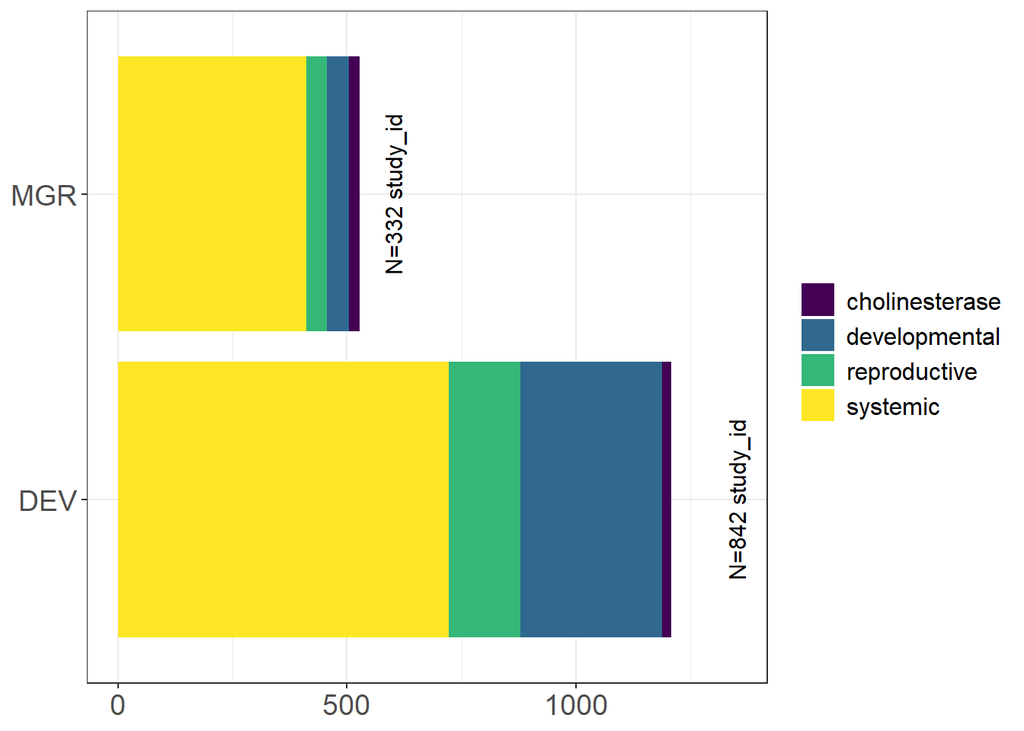

```r
endpoint_category_counts <- ggplot()+
  geom_bar(data=mgr.dev.list.mins, aes(y=study_type, fill=endpoint_category))+
  theme_bw()+
  annotate(geom='text', x=600, y=2, label='N=332 study_id', size=4, angle=90)+
  annotate(geom='text', x=1350, y=1, label='N=842 study_id', size=4, angle=90)+
  theme(legend.title = element_blank(),
        axis.text = element_text(size=14),
        #axis.text.x = element_text(angle=75, hjust=1),
        axis.title.x = element_blank(),
        axis.title.y = element_blank(),
        legend.text = element_text(size=12))+
  scale_fill_viridis(discrete=TRUE, option = 'a')


endpoint_category_counts
```

## 2.1 Collapse to effects at lowest critical effect level in the study

```r
mgr.dev.list.mins[, endpoint_categories_at_ce := paste0(endpoint_category, collapse=', '), by=c('study_id')]

#length(unique(mgr.dev.list.mins[grep('systemic',endpoint_categories_at_ce)]$study_id)) #1023
#length(unique(mgr.dev.list.mins[!grep('systemic',endpoint_categories_at_ce)]$study_id)) #147
#length(unique(mgr.dev.list.mins$study_id)) #1170

mgr.dev.list.mins[grepl('systemic',endpoint_categories_at_ce), systemic_at_ce := TRUE]
mgr.dev.list.mins[grepl('reproductive', endpoint_categories_at_ce), repro_dev_at_ce := TRUE]
mgr.dev.list.mins[grepl('developmental', endpoint_categories_at_ce), repro_dev_at_ce := TRUE]
mgr.dev.list.mins[grepl('cholinesterase', endpoint_categories_at_ce), cholinesterase_at_ce := TRUE]
mgr.dev.list.mins[repro_dev_at_ce==TRUE & systemic_at_ce==TRUE, both_at_ce := TRUE]
mgr.dev.list.mins[is.na(repro_dev_at_ce) & is.na(cholinesterase_at_ce) & systemic_at_ce==TRUE, systemic_only_at_ce := TRUE]
mgr.dev.list.mins[is.na(repro_dev_at_ce) & is.na(systemic_at_ce) & cholinesterase_at_ce==TRUE, cholinesterase_only_at_ce := TRUE]
mgr.dev.list.mins[is.na(cholinesterase_at_ce) & is.na(systemic_at_ce), repro_dev_only_at_ce := TRUE]
mgr.dev.list.mins[is.na(systemic_at_ce) & repro_dev_at_ce ==TRUE & cholinesterase_at_ce==TRUE, repro_dev_chol_at_ce := TRUE]
```

- Total DEV and MGR studies = 1170
- Total DEV and MGR studies with systemic effects at CE level = 1023

```r
length(unique(mgr.dev.list.mins$study_id)) #1170
```

```
## [1] 1170
```

```r
length(unique(mgr.dev.list.mins[systemic_at_ce==TRUE]$study_id)) #1023
```

```
## [1] 1023
```

## 2.2 Counts for all DEV and MGR

```r
length(unique(mgr.dev.list.mins[systemic_only_at_ce==TRUE]$study_id)) #670
```

```
## [1] 670
```

```r
length(unique(mgr.dev.list.mins[both_at_ce==TRUE]$study_id)) #344
```

```
## [1] 344
```

```r
length(unique(mgr.dev.list.mins[repro_dev_only_at_ce==TRUE]$study_id)) #115
```

```
## [1] 115
```

```r
length(unique(mgr.dev.list.mins[cholinesterase_only_at_ce==TRUE]$study_id)) #31
```

```
## [1] 31
```

```r
length(unique(mgr.dev.list.mins[repro_dev_chol_at_ce==TRUE]$study_id)) #1
```

```
## [1] 1
```

```r
length(unique(mgr.dev.list.mins[cholinesterase_at_ce==TRUE & systemic_at_ce==TRUE & is.na(repro_dev_at_ce)]$study_id)) #9
```

```
## [1] 9
```

```r
length(unique(mgr.dev.list.mins[study_type=='DEV']$study_id)) #839
```

```
## [1] 839
```

```r
length(unique(mgr.dev.list.mins[study_type=='DEV' & systemic_at_ce==TRUE]$study_id)) #721
```

```
## [1] 721
```

```r
721/839 #86%
```

```
## [1] 0.8593564
```

## 2.3 Counts for DEV

```r
length(unique(mgr.dev.list.mins[study_type=='DEV' & systemic_only_at_ce==TRUE]$study_id)) #429 DEV studies with only systemic effects at CE
```

```
## [1] 429
```

```r
429/839
```

```
## [1] 0.511323
```

```r
length(unique(mgr.dev.list.mins[study_type=='DEV' & both_at_ce==TRUE]$study_id)) #287
```

```
## [1] 287
```

```r
287/839
```

```
## [1] 0.3420739
```

```r
length(unique(mgr.dev.list.mins[study_type=='DEV' & repro_dev_only_at_ce==TRUE]$study_id)) #103
```

```
## [1] 103
```

```r
length(unique(mgr.dev.list.mins[study_type=='DEV' & cholinesterase_only_at_ce==TRUE]$study_id)) #14
```

```
## [1] 14
```

```r
length(unique(mgr.dev.list.mins[study_type=='DEV' & repro_dev_chol_at_ce==TRUE]$study_id)) #1
```

```
## [1] 1
```

```r
length(unique(mgr.dev.list.mins[study_type=='DEV' & cholinesterase_at_ce==TRUE & systemic_at_ce==TRUE & is.na(repro_dev_at_ce)]$study_id)) #5
```

```
## [1] 5
```

```r
#429+287+103+14+1+5=839
#103/839
```

## 2.4 Counts for MGR

```r
length(unique(mgr.dev.list.mins[study_type=='MGR']$study_id)) #331 total MGR studies
```

```
## [1] 331
```

```r
length(unique(mgr.dev.list.mins[study_type=='MGR' & systemic_at_ce==TRUE]$study_id)) #302
```

```
## [1] 302
```

```r
#241+57+12+17+4 = 331

length(unique(mgr.dev.list.mins[study_type=='MGR' & systemic_only_at_ce==TRUE]$study_id)) #241 MGR studies with only systemic effects at CE
```

```
## [1] 241
```

```r
241/331
```

```
## [1] 0.7280967
```

```r
length(unique(mgr.dev.list.mins[study_type=='MGR' & both_at_ce==TRUE]$study_id)) #57
```

```
## [1] 57
```

```r
57/331
```

```
## [1] 0.1722054
```

```r
length(unique(mgr.dev.list.mins[study_type=='MGR' & repro_dev_only_at_ce==TRUE]$study_id)) #12
```

```
## [1] 12
```

```r
12/331
```

```
## [1] 0.03625378
```

```r
length(unique(mgr.dev.list.mins[study_type=='MGR' & cholinesterase_only_at_ce==TRUE]$study_id)) #17
```

```
## [1] 17
```

```r
length(unique(mgr.dev.list.mins[study_type=='MGR' & repro_dev_chol_at_ce==TRUE]$study_id)) #0
```

```
## [1] 0
```

```r
length(unique(mgr.dev.list.mins[study_type=='MGR' & cholinesterase_at_ce==TRUE & systemic_at_ce==TRUE & is.na(repro_dev_at_ce)]$study_id)) #4
```

```
## [1] 4
```

# 3 Make Figure 1

```r
DEV <- c(429,287,103,14,1,5)
MGR <- c(241,57,12,17,0,4)
CE <- c('systemic only','systemic & reprod/dev', 'repro/dev only','cholinesterase only','repro/dev & cholinesterase', 'systemic & cholinesterase')

data.table(DEV, MGR, CE)
```

| DEV | MGR | CE |
| --- | --- | --- |
| 429 | 241 | systemic only |
| 287 | 57 | systemic & reprod/dev |
| 103 | 12 | repro/dev only |
| 14 | 17 | cholinesterase only |
| 1 | 0 | repro/dev & cholinesterase |
| 5 | 4 | systemic & cholinesterase |

```r
ce.summary <- data.table(study_type=rep(c('DEV','MGR'), each=6), ce_type = c('systemic only','systemic & repro/dev', 'repro/dev only','cholinesterase only','repro/dev & cholinesterase', 'systemic & cholinesterase','systemic only','systemic & repro/dev', 'repro/dev only','cholinesterase only','repro/dev & cholinesterase', 'systemic & cholinesterase'),
                         study_number = c(429,287,103,14,1,5,241,57,12,17,0,4 ))

ce.summary
```

| study_type | ce_type | study_number |
| --- | --- | --- |
| DEV | systemic only | 429 |
| DEV | systemic & repro/dev | 287 |
| DEV | repro/dev only | 103 |
| DEV | cholinesterase only | 14 |
| DEV | repro/dev & cholinesterase | 1 |
| DEV | systemic & cholinesterase | 5 |
| MGR | systemic only | 241 |
| MGR | systemic & repro/dev | 57 |
| MGR | repro/dev only | 12 |
| MGR | cholinesterase only | 17 |

[output cut: 2 more lines]

- Here we are showing just the endpoint categories that informed the minimum critical effect for the study (could be more than one LOAEL by lifestage), and if they are systemic or non-systemic
- for a vast majority of studies, some systemic effects are observed at the study’s minimum critical effect.

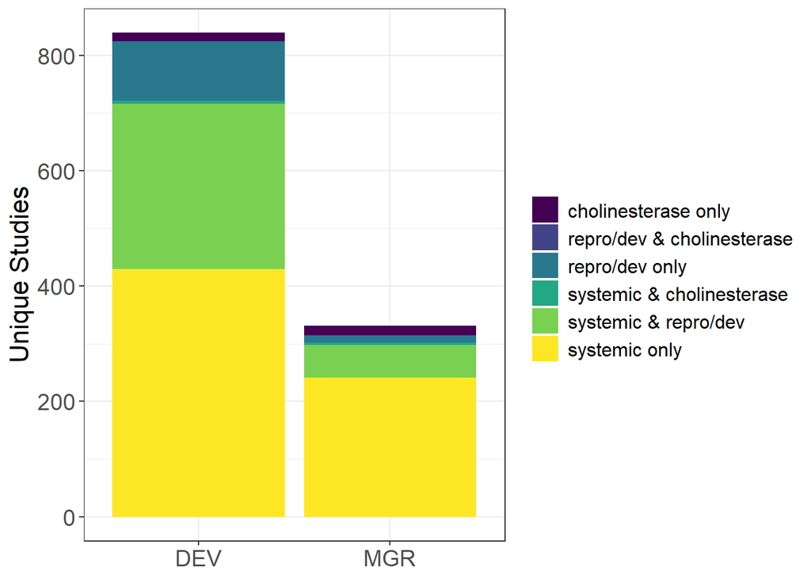

```r
ce_summary <- ggplot(ce.summary, aes(study_type,study_number, fill=ce_type))+
  geom_col()+
  theme_bw()+
  theme(legend.title = element_blank(),
        axis.text = element_text(size=14),
        axis.title.x = element_blank(),
        axis.title.y = element_text(size=16),
        legend.text = element_text(size=12))+
  scale_fill_viridis(discrete=TRUE)+
  labs(y='Unique Studies')

  #annotate(geom='text', x=1, y=860, label='742, 97', size=4)+
  #annotate(geom='text', x=2, y=350, label='302, 29', size=4)

ce_summary
```

# 4 Reproducibility and files

```r
list_data <- list('mgr_dev_loael_toxrefdb_2_1' = as.data.frame(mgr.dev.ce),
                  'mgr_dev_CEs' = as.data.frame(mgr.dev.list),
                  'mgr_dev_CE_mins_only' = as.data.frame(mgr.dev.list.mins),
                  'ce_summary_graph' = as.data.frame(ce.summary))



write.xlsx(list_data, file='./output/draft_data_toxrefdb_v2_1_mgr_dev_systemic_analysis_14Dec2023.xlsx')
```